# MA304 Assignment 1

### **INTRODUCTION**

The data consist of 2383 incidences with available information on 47 variables in the city of Dallas. The purpose of this report is to understand the factors that will affect the policing equity. The primary focus of Policing equity is to bridge the gap created by issues of communication, suffering and generational distrust, and to forge a path to public health and safety, trust in the community and racial equality. The use of the different approaches and the relationship between variables have been clarified in this study. Importing the dataset and providing a basic understanding of the dataset is always the first step of the data analysis. The next step is to analyze the data set using various variables and then use graphs to illustrate the relationship between those variables.

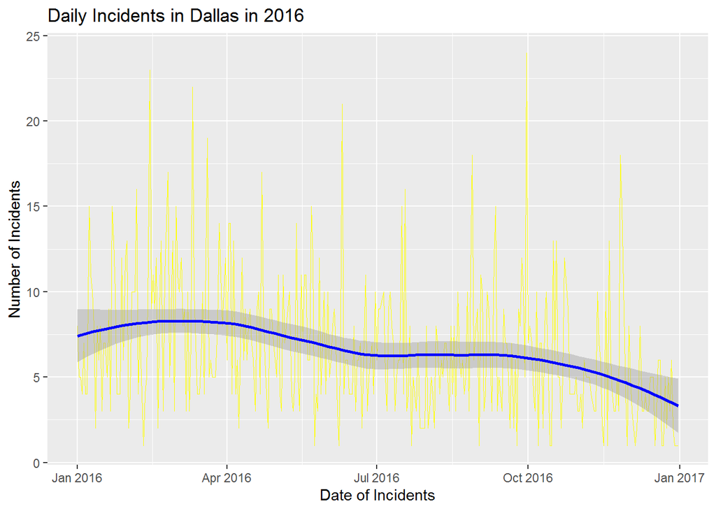

The graph in figure (1) shows the number of incidents of offences in Dallas in the year 2016. It is evident, as an overall trend, that the number of incidences increased relatively rapidly until March, and then began to decrease speedily until mid-2016. For almost a quarter, this pattern remained steady before dropping at a very high pace until December. By the end of the year, very few incidences of offense were recorded.

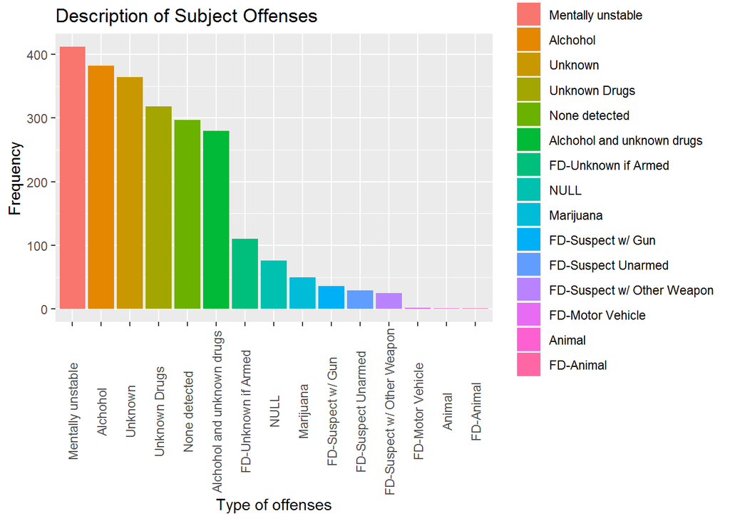

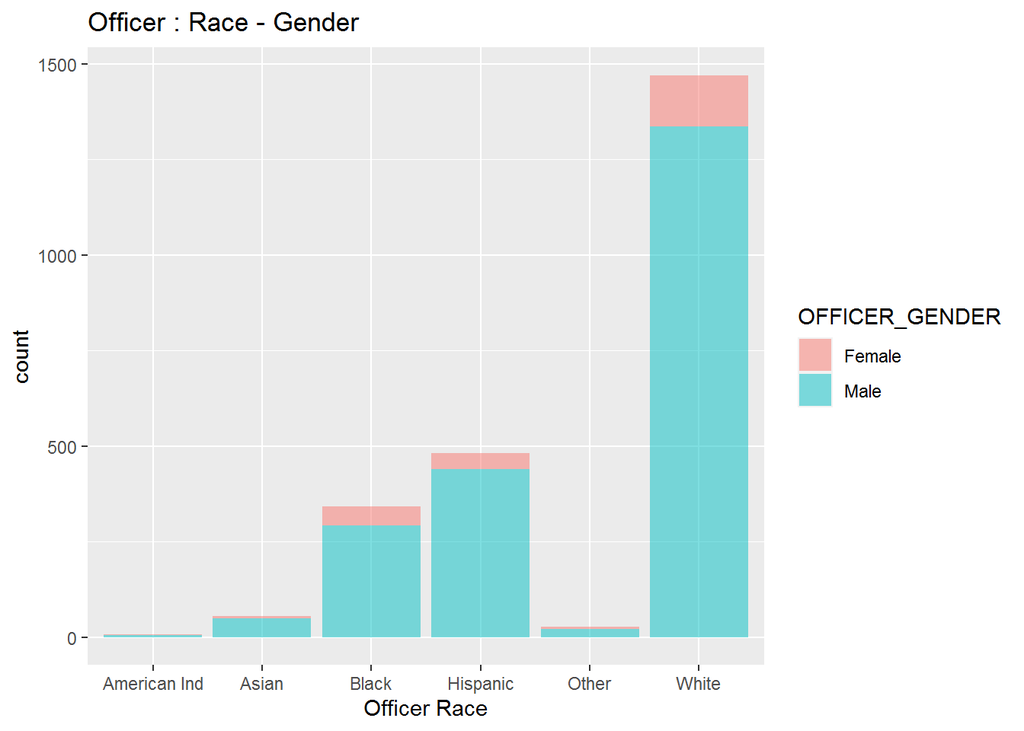